# Module_11_maf_tools

#### 9.2 Detecting cancer driver genes based on positional clustering

maftools function oncodrive - identifies cancer genes (driver) from a MAF. Is based on an algorithm oncodriveCLUST which was originally implemented in Pythin. Concept based on the fact that most of variants in cancer causing genes are enriched at few specific loci (hot-spots). Takes advantage of positions to identify cancer gene drivers:

```r
# run oncodrive with protein change and z-score to find what genes are enriched
laml.sig = oncodrive(maf = laml, AACol = 'Protein_Change', minMut = 5, pvalMethod = 'zscore')
```

```
## Estimating background scores from synonymous variants..
```

```
## Not enough genes to build background. Using predefined values. (Mean = 0.279; SD = 0.13)
```

```
## Estimating cluster scores from non-syn variants..
```

```
## Comapring with background model and estimating p-values..
```

```
## Done !
```

```r
head(laml.sig)
```

```
##    Hugo_Symbol Frame_Shift_Del Frame_Shift_Ins In_Frame_Del In_Frame_Ins
## 1:        IDH1               0               0            0            0
## 2:        IDH2               0               0            0            0
## 3:        NPM1               0              33            0            0
## 4:        NRAS               0               0            0            0
## 5:       U2AF1               0               0            0            0
## 6:         KIT               1               1            0            1
##    Missense_Mutation Nonsense_Mutation Splice_Site total MutatedSamples
## 1:                18                 0           0    18             18
## 2:                20                 0           0    20             20
## 3:                 1                 0           0    34             33
## 4:                15                 0           0    15             15
## 5:                 8                 0           0     8              8
## 6:                 7                 0           0    10              8
##    AlteredSamples clusters muts_in_clusters clusterScores protLen   zscore
## 1:             18        1               18     1.0000000     414 5.546154
## 2:             20        2               20     1.0000000     452 5.546154
## 3:             33        2               32     0.9411765     294 5.093665
## 4:             15        2               15     0.9218951     189 4.945347
## 5:              8        1                7     0.8750000     240 4.584615
## 6:              8        2                9     0.8500000     976 4.392308
##            pval          fdr fract_muts_in_clusters
## 1: 1.460110e-08 1.022077e-07              1.0000000
## 2: 1.460110e-08 1.022077e-07              1.0000000
## 3: 1.756034e-07 8.194826e-07              0.9411765
## 4: 3.800413e-07 1.330144e-06              1.0000000
## 5: 2.274114e-06 6.367520e-06              0.8750000
## 6: 5.607691e-06 1.308461e-05              0.9000000
```

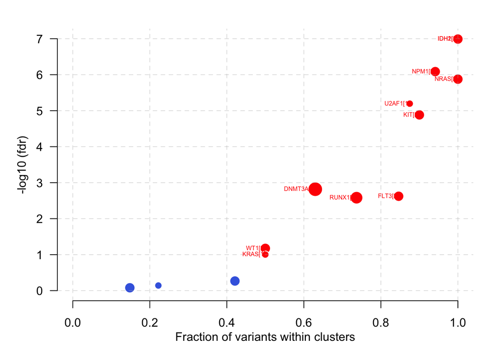

```r
# plot the results as scatter plot
plotOncodrive(res = laml.sig, fdrCutOff = 0.1, useFraction = TRUE, labelSize = 0.5)
```

#### 9.3 Adding and summarizing pfam domains

pfamDomains adds pfam domain information to AA changes and summarizes AA changes according to the domains affected. Able to find what domain in cancer cohort is most frequently affected.

```r
laml.pfam = pfamDomains(maf = laml, AACol = "Protein_Change", top = 10)
```

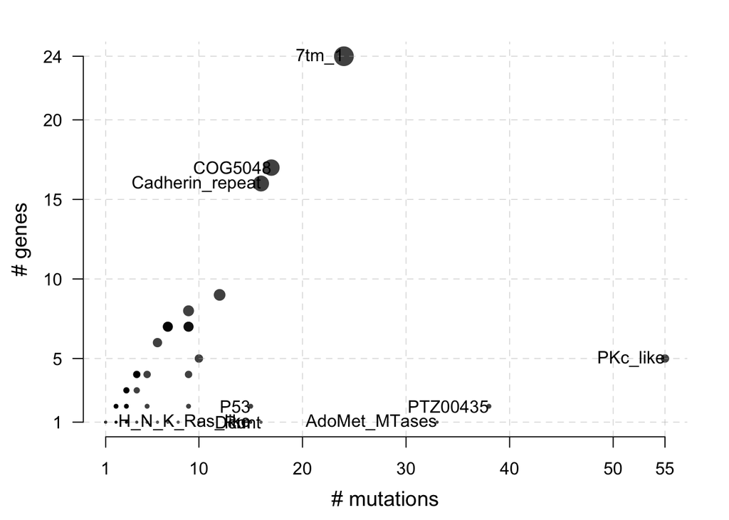

```r
#Protein summary (Printing first 7 columns)
laml.pfam$proteinSummary[,1:7, with = FALSE]
```

```
##         HGNC AAPos Variant_Classification  N total  fraction   DomainLabel
##    1: DNMT3A   882      Missense_Mutation 27    54 0.5000000 AdoMet_MTases
##    2:   IDH1   132      Missense_Mutation 18    18 1.0000000      PTZ00435
##    3:   IDH2   140      Missense_Mutation 17    20 0.8500000      PTZ00435
##    4:   FLT3   835      Missense_Mutation 14    52 0.2692308      PKc_like
##    5:   FLT3   599           In_Frame_Ins 10    52 0.1923077      PKc_like
##   ---
## 1512: ZNF646   875      Missense_Mutation  1     1 1.0000000          <NA>
## 1513: ZNF687   554      Missense_Mutation  1     2 0.5000000          <NA>
## 1514: ZNF687   363      Missense_Mutation  1     2 0.5000000          <NA>
## 1515: ZNF75D     5      Missense_Mutation  1     1 1.0000000          <NA>
## 1516: ZNF827   427        Frame_Shift_Del  1     1 1.0000000          <NA>
```

```r
#Domain summary (printing first 3 columns)
laml.pfam$domainSummary[,1:3, with = FALSE]
```

```
##        DomainLabel nMuts nGenes
##   1:      PKc_like    55      5
##   2:      PTZ00435    38      2
##   3: AdoMet_MTases    33      1
##   4:         7tm_1    24     24
##   5:       COG5048    17     17
##  ---
## 499:    ribokinase     1      1
## 500:   rim_protein     1      1
## 501: sigpep_I_bact     1      1
## 502:           trp     1      1
## 503:        zf-BED     1      1
```

#### 9.4 Survival Analysis

mafSurvive performs survival analysis and draws kaplan meier curve by grouping samples based on mutation status of user defined gene(s) or maunally provided samples. input data must contain Tumor_Sample_Barcode (make sure they match in the MAF files), binary event (1/0), and time of event.

This example annotation data already contains survival information. If we have survival data stored in separate table provide via argument clinicalData ##### 9.4.1 Mutation in any given genes

```r
#Survival analysis based on grouping of DNMT3A mutation status
laml.maf <- system.file("extdata", "tcga_laml.maf.gz", package = "maftools")
laml.clin <- system.file("extdata", "tcga_laml_annot.tsv", package = "maftools")
laml <- read.maf(maf = laml.maf,  clinicalData = laml.clin)
```

```
## -Reading
## -Validating
## -Silent variants: 475
## -Summarizing
## -Processing clinical data
## -Finished in 0.088s elapsed (0.080s cpu)
```

```r
mafSurvival(maf = laml, genes = 'DNMT3A', time = 'days_to_last_followup', Status = 'Overall_Survival_Status', isTCGA = TRUE)
```

```
## Looking for clinical data in annoatation slot of MAF..
```

```
## Number of mutated samples for given genes:
```

```
## DNMT3A
##     48
```

```
## Removed 11 samples with NA's
```

```
## Median survival..
```

```
##     Group medianTime   N
## 1: Mutant        245  45
## 2:     WT        396 137
```

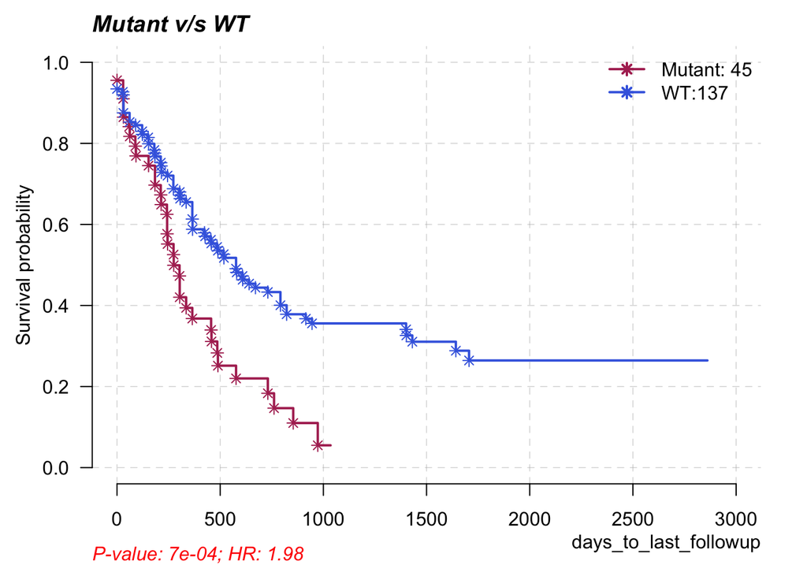

##### 9.4.2 Predict gene sets associated with survival

```r
#Using top 20 mutated genes to identify a set of genes (of size 2) to predict poor prognostic groups
prog_geneset = survGroup(maf = laml, top = 20, geneSetSize = 2, time = "days_to_last_followup", Status = "Overall_Survival_Status", verbose = FALSE)
```

```
## Removed 11 samples with NA's
```

```r
# combination (N=2) of genes associated with poor survival (P<0.05).
print(prog_geneset)
```

```
##     Gene_combination P_value    hr  WT Mutant
##  1:      FLT3_DNMT3A 0.00104 2.510 164     18
##  2:      DNMT3A_SMC3 0.04880 2.220 176      6
##  3:      DNMT3A_NPM1 0.07190 1.720 166     16
##  4:      DNMT3A_TET2 0.19600 1.780 176      6
##  5:        FLT3_TET2 0.20700 1.860 177      5
##  6:        NPM1_IDH1 0.21900 0.495 176      6
##  7:      DNMT3A_IDH1 0.29300 1.500 173      9
##  8:       IDH2_RUNX1 0.31800 1.580 176      6
##  9:        FLT3_NPM1 0.53600 1.210 165     17
## 10:      DNMT3A_IDH2 0.68000 0.747 178      4
## 11:      DNMT3A_NRAS 0.99200 0.986 178      4
```

```
## Looking for clinical data in annoatation slot of MAF..
## Removed 11 samples with NA's
```

```
## Median survival..
```

```
##     Group medianTime   N
## 1: Mutant      242.5  18
## 2:     WT      379.5 164
```

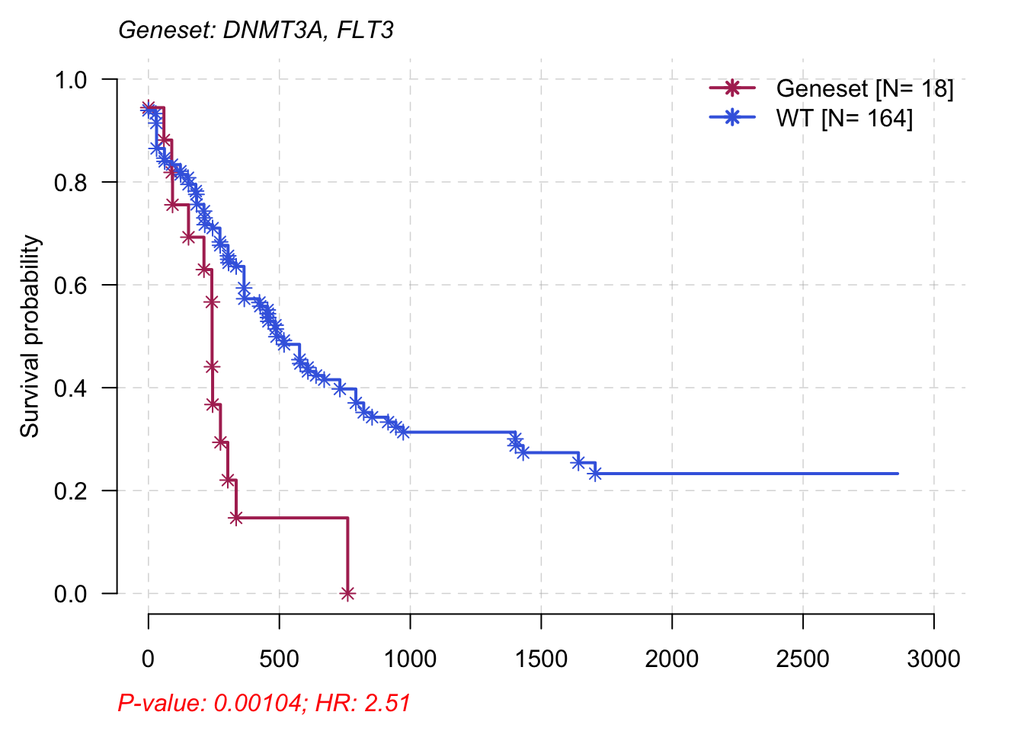

```r
# Draw KM curves
mafSurvGroup(maf = laml, geneSet = c("DNMT3A", "FLT3"), time = "days_to_last_followup", Status = "Overall_Survival_Status")
```

#### 9.5 Comparing 2 Cohorts

Cancers differ from each other in terms of their mutation pattern. We compare 2 different cohorts to detect differentially mutated genes. Ex: Madan et. al showed patients with relapsed APL (acute promyelocytic Leukemia) tends to have mutations in PML and RARA genes, which were absent during primary stage of disease. Difference between 2 cohorts (primary v relapsed APL) can be detected using mafCompare mafCompare - performs fisher test on all genes between 2 cohorts to detect differentially mutated genes

```r
#Primary APL MAF
primary.apl = system.file("extdata", "APL_primary.maf.gz", package = "maftools")
primary.apl = read.maf(maf = primary.apl)
```

```
## -Reading
## -Validating
## --Non MAF specific values in Variant_Classification column:
##   ITD
## -Silent variants: 45
## -Summarizing
## -Processing clinical data
## --Missing clinical data
## -Finished in 0.037s elapsed (0.033s cpu)
```

```r
# Relapse APL MAF
relapse.apl = system.file("extdata", "APL_relapse.maf.gz", package = "maftools")
relapse.apl = read.maf(maf = relapse.apl)
```

```
## -Reading
## -Validating
## --Non MAF specific values in Variant_Classification column:
##   ITD
## -Silent variants: 19
## -Summarizing
## -Processing clinical data
## --Missing clinical data
## -Finished in 0.025s elapsed (0.021s cpu)
```

```r
#Considering only genes which are mutated in at-least 5 samples in 1 cohort to avoid bias due to genes mutated in single sample
pt.vs.rt <- mafCompare(m1 = primary.apl, m2 = relapse.apl, m1Name = 'Primary', m2Name = 'Relapse', minMut = 5)
print(pt.vs.rt)
```

```
## $results
##    Hugo_Symbol Primary Relapse         pval         or       ci.up      ci.low
## 1:         PML       1      11 1.529935e-05 0.03537381   0.2552937 0.000806034
## 2:        RARA       0       7 2.574810e-04 0.00000000   0.3006159 0.000000000
## 3:       RUNX1       1       5 1.310500e-02 0.08740567   0.8076265 0.001813280
## 4:        FLT3      26       4 1.812779e-02 3.56086275  14.7701728 1.149009169
## 5:      ARID1B       5       8 2.758396e-02 0.26480490   0.9698686 0.064804160
## 6:         WT1      20      14 2.229087e-01 0.60619329   1.4223101 0.263440988
## 7:        KRAS       6       1 4.334067e-01 2.88486293 135.5393108 0.337679367
## 8:        NRAS      15       4 4.353567e-01 1.85209500   8.0373994 0.553883512
## 9:      ARID1A       7       4 7.457274e-01 0.80869223   3.9297309 0.195710173
##         adjPval
## 1: 0.0001376942
## 2: 0.0011586643
## 3: 0.0393149868
## 4: 0.0407875250
## 5: 0.0496511201
## 6: 0.3343630535
## 7: 0.4897762916
## 8: 0.4897762916
## 9: 0.7457273717
##
## $SampleSummary
##     Cohort SampleSize
## 1: Primary        124
## 2: Relapse         58
```

#### 9.5.1 Forest Plots

Use forest plots to visualize the results of primary vs relapse APL for PML and RARA

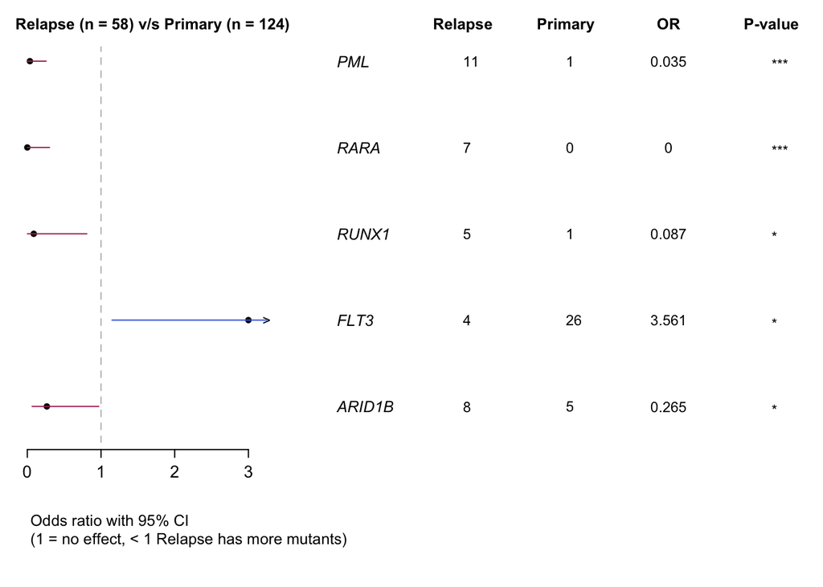

```r
# visualize the results of primary vs relapse APL for PML and RARA
forestPlot(mafCompareRes = pt.vs.rt, pVal = 0.1)
```

#### 9.5.2 Co-onco plots

alternative way to display results is by plotting 2 oncoplots side by side. coOncoplot function takes 2 mafs and plots them side by side for better comparison

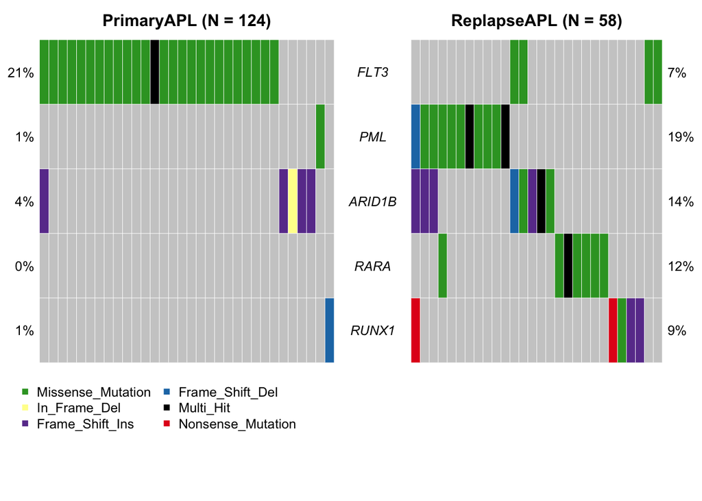

```r
genes = c("PML", "RARA", "RUNX1", "ARID1B", "FLT3")
coOncoplot(m1 = primary.apl, m2 = relapse.apl, m1Name = 'PrimaryAPL', m2Name = 'ReplapseAPL', genes = genes, removeNonMutated = TRUE)
```

#### 9.5.3 Co-bar plots

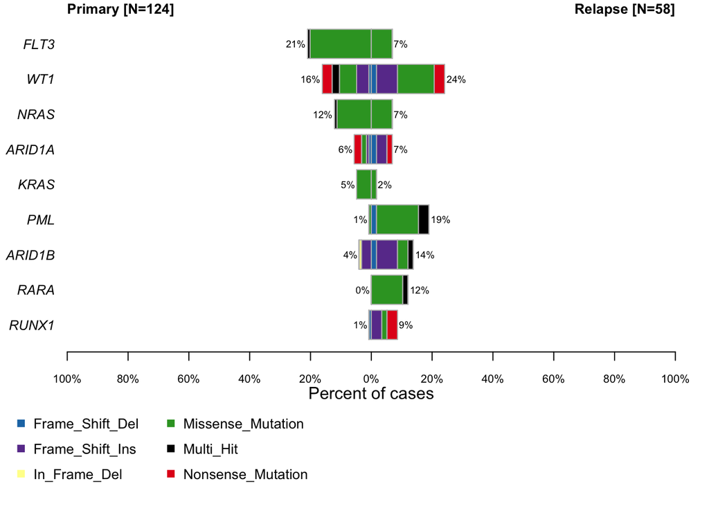

```r
coBarplot(m1 = primary.apl, m2 = relapse.apl, m1Name = "Primary", m2Name = "Relapse")
```

#### 9.5.4 Lollipop plot-2

Along with plots showing cohort-wise differences. Its also possible to show gene-wise differences with lollipopPlot2 function

```
## Gene: PML
```

```
## 9 transcripts available. Use arguments refSeqID or proteinID to manually specify tx name.
```

```
##    HGNC refseq.ID protein.ID aa.length
## 1:  PML NM_002675  NP_002666       633
## 2:  PML NM_033238  NP_150241       882
## 3:  PML NM_033239  NP_150242       829
## 4:  PML NM_033240  NP_150243       611
## 5:  PML NM_033244  NP_150247       560
## 6:  PML NM_033246  NP_150249       423
## 7:  PML NM_033247  NP_150250       435
## 8:  PML NM_033249  NP_150252       585
## 9:  PML NM_033250  NP_150253       781
```

```
## Using longer transcript NM_033238 for now.
## 9 transcripts available. Use arguments refSeqID or proteinID to manually specify tx name.
```

```
##    HGNC refseq.ID protein.ID aa.length
## 1:  PML NM_002675  NP_002666       633
## 2:  PML NM_033238  NP_150241       882
## 3:  PML NM_033239  NP_150242       829
## 4:  PML NM_033240  NP_150243       611
## 5:  PML NM_033244  NP_150247       560
## 6:  PML NM_033246  NP_150249       423
## 7:  PML NM_033247  NP_150250       435
## 8:  PML NM_033249  NP_150252       585
## 9:  PML NM_033250  NP_150253       781
```

```
## Using longer transcript NM_033238 for now.
```

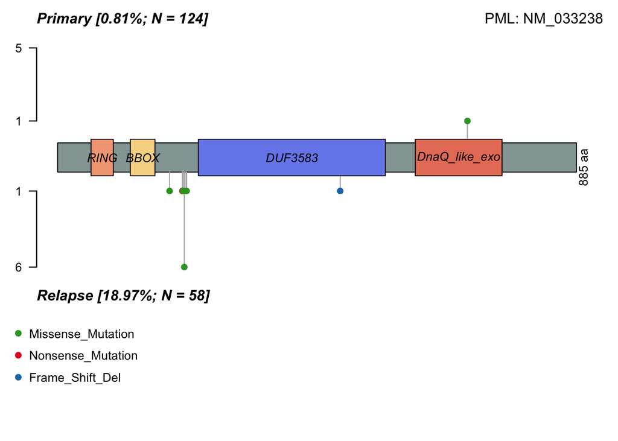

```r
lollipopPlot2(m1 = primary.apl, m2 = relapse.apl, gene = "PML", AACol1 = "amino_acid_change", AACol2 = "amino_acid_change", m1_name = "Primary", m2_name = "Relapse")
```

#### 9.6 Clinical Enrichment Analysis

clinicalEnrichment is a function that takes clinical feature associated with the samples and performs enrichment analysis. It performs various groupwise and pairwise comparisons to identify enriched mutations for every category within a clinical feature. Below ex identifies mutations associated with FAB_classification

```r
fab.ce = clinicalEnrichment(maf = laml, clinicalFeature = 'FAB_classification')
```

```
## Sample size per factor in FAB_classification:
```

```
##
## M0 M1 M2 M3 M4 M5 M6 M7
## 19 44 44 21 39 19  3  3
##      Hugo_Symbol Feature_1 Feature_2 n_mutated_Feature1 n_mutated_Feature2 fdr
##   1:        FLT3        M1        M0           15 of 44            4 of 19   1
##   2:        FLT3        M2        M0            8 of 44            4 of 19   1
##   3:        FLT3        M3        M0            6 of 21            4 of 19   1
##   4:        FLT3        M4        M0           13 of 39            4 of 19   1
##   5:        FLT3        M5        M0            6 of 19            4 of 19   1
##  ---
## 617:         TTN      <NA>      <NA>               <NA>               <NA>  NA
## 618:         TTN      <NA>      <NA>               <NA>               <NA>  NA
## 619:         TTN      <NA>      <NA>               <NA>               <NA>  NA
## 620:         TTN      <NA>      <NA>               <NA>               <NA>  NA
## 621:         TTN      <NA>      <NA>               <NA>               <NA>  NA
```

[output cut: 24 more lines]

```r
#Results are returned as a list. Significant associations p-value < 0.05
fab.ce$groupwise_comparision[p_value < 0.05]
```

```
##    Hugo_Symbol Group1 Group2 n_mutated_group1 n_mutated_group2      p_value
## 1:        IDH1     M1   Rest         11 of 44         7 of 149 0.0002597371
## 2:        TP53     M7   Rest           3 of 3        12 of 190 0.0003857187
## 3:      DNMT3A     M5   Rest         10 of 19        38 of 174 0.0089427384
## 4:       CEBPA     M2   Rest          7 of 44         6 of 149 0.0117352110
## 5:       RUNX1     M0   Rest          5 of 19        11 of 174 0.0117436825
## 6:        NPM1     M5   Rest          7 of 19        26 of 174 0.0248582372
## 7:        NPM1     M3   Rest          0 of 21        33 of 172 0.0278630823
## 8:      DNMT3A     M3   Rest          1 of 21        47 of 172 0.0294005111
##          OR      OR_low    OR_high       fdr
## 1: 6.670592 2.173829026 21.9607250 0.0308575
## 2:      Inf 5.355415451        Inf 0.0308575
## 3: 3.941207 1.333635173 11.8455979 0.3757978
## 4: 4.463237 1.204699322 17.1341278 0.3757978
## 5: 5.216902 1.243812880 19.4051505 0.3757978
## 6: 3.293201 1.001404899 10.1210509 0.5880102
## 7: 0.000000 0.000000000  0.8651972 0.5880102
## 8: 0.133827 0.003146708  0.8848897 0.5880102
```

Results shows IDH1 muts are enriched in M1 subtype of leukemia compared to the rest of the cohort. DNMT3A is in M5, RUNX1 is in M0, etc. (is well known and function recaptures the results). Next we plot the results:

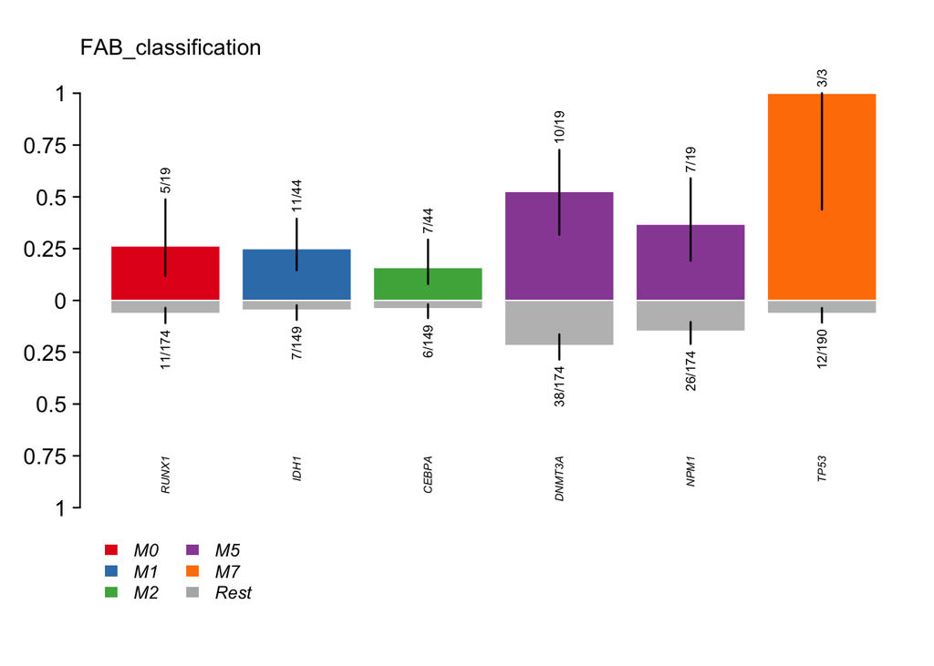

```r
plotEnrichmentResults(enrich_res = fab.ce, pVal = 0.05, geneFontSize = 0.5, annoFontSize = 0.6)
```

#### 9.7 Drug-Gene Interactions

drugInteractions function checks for drug-gene interactions and gene druggability information compiled from “Drug Gene interactions” database

```r
dgi = drugInteractions(maf = laml, fontSize = 0.75)
```

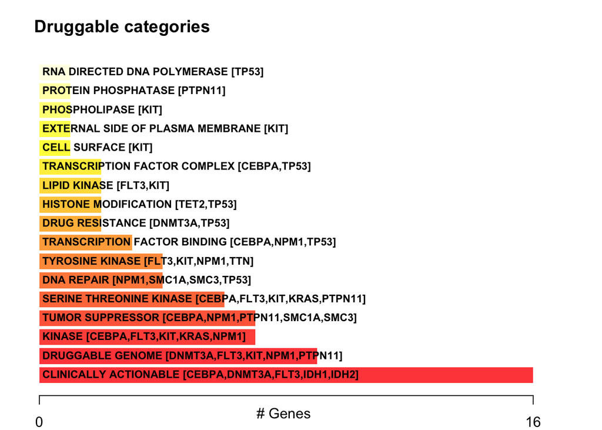

Plot shows potential druggable gene categories along with top 5 genes involved in them. Can also extract information on drug-gene interactions Ex: below is the results for known/reported drugs to interact with DNMT3A

```r
dnmt3a.dgi = drugInteractions(genes = "DNMT3A", drugs = TRUE)
```

```
## Number of claimed drugs for given genes:
##      Gene N
## 1: DNMT3A 7
```

```r
# Printing selected columns
dnmt3a.dgi[,.(Gene, interaction_types, drug_name, drug_claim_name)]
```

```
##      Gene interaction_types    drug_name drug_claim_name
## 1: DNMT3A                                            N/A
## 2: DNMT3A                   DAUNORUBICIN    Daunorubicin
## 3: DNMT3A                     DECITABINE      Decitabine
## 4: DNMT3A                     IDARUBICIN      IDARUBICIN
## 5: DNMT3A                     DECITABINE      DECITABINE
## 6: DNMT3A         inhibitor   DECITABINE   CHEMBL1201129
## 7: DNMT3A         inhibitor  AZACITIDINE      CHEMBL1489
```

#### 9.8 Oncogenic Signaling Pathways

pathways function checks for enrichment of known Oncogenic Signaling Pathways from TCGA cohorts.

```
## Summarizing signalling pathways [Sanchez-Vega et al., https://doi.org/10.1016/j.cell.2018.03.035]
```

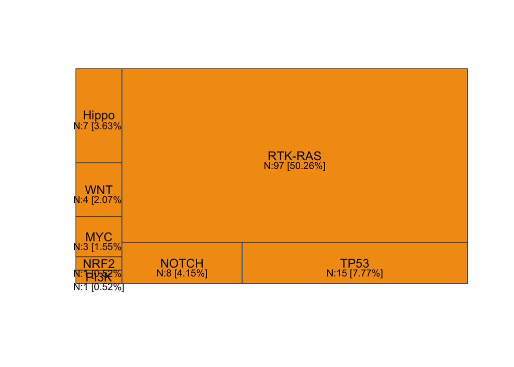

```r
# There is no fucntion pathways or plotPathways with maftools. Now it is OncogenicPathways and plotOncogenicPathways
pws = pathways(maf = laml, plotType = 'treemap')
```

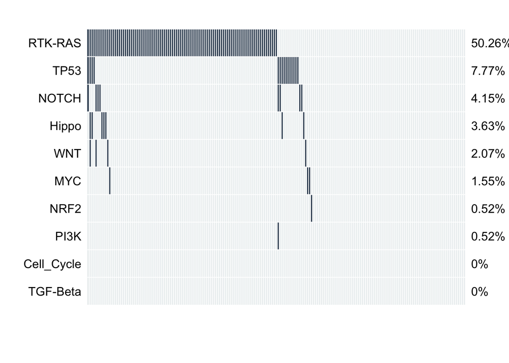

```r
plotPathways(maf = laml, pathlist = pws)
```